# Credit Booms Gone Bust: Monetary Policy, Leverage Cycles, and Financial Crises

Moritz Schularick and Alan M. Taylor

April 2012 @ AER

#### The role of money and credit in macroeconomics

1. Money view: Friedman and Schwartz (1963)
2. Credit view: Mishkin (1978), Bernanke (1983), Gertler (1988)
   1. Passive credit: credit as an enhancement mechanism (financial accelerator effect)
   2. Endogenous credit cycles: financial system itself generate booms and busts (Minsky’s view)

#### Two eras of financial capitalism

1. 1870-1939: money and credit maintained a roughly stable relationship to each other.
2. 1945-Now: credit decoupled from broad money
   1. Shift away from gold to fiat money, the greater role of activist macroeconomic policies, the greater bank supervision and deposit insurance, the expanded role of the lender of last resort.
   2. Banks use new sources of funding, mainly debt securities, creating more and more nonmonetary bank liabilities.
   3. Banking stability can no longer rest on the foundations of deposit issuance alone, with the lender of last resort now having to confront wholesale (non-deposit) bank runs.

**Event analysis**

1. In postwar era, irregular deleveraging of the financial sector was avoid, aggregate money and loan growth remained relatively high.
2. Total bank assets, which rely on nonmoney funding to a greater extent, have actually become more volatile in the postwar era.
3. Despite the much more aggressive policy response, the cumulative real effects have been even somewhat stronger in the postwar period. In the earlier decades, the financial sector played a less central role, and financial crises were less costly.
4. Recessions after WW2 have become less frequent, but not less severe.

#### Credit booms and financial crisis

Does a country’s recent history of credit growth help predict a financial crisis?

$$\text{logit}(\text{CRISIS}_{it}=1) =
b_{0i} + b_1(L)\log\text{CREDIT}_{it} + b_2(L) X_{it} + \epsilon_{it}$$

$X_{it}$ includes real GDP growth, inflation rate, interest rate, investment/GDP.

**Receiver Operating Characteristic (ROC)**

True Positive Rate (Sensitivity):

$$\text{TPR} = \frac{\text{True Positive}}{\text{Actual Positive}}$$

False Positive Rate (Fall-out):

$$\text{FPR} = \frac{\text{False Positive}}{\text{Actual Negative}}
= 1 - \frac{\text{True Negative}}{\text{Actual Negative}} = 1-\text{TNR}$$

Binary classifier: $I(\hat p - \theta > 0)$, $\hat p$ is the estimated probability of crisis, $\theta$ is a varying threshold. $\theta\to 0$, the classifier is aggressive, TPR$\to 1$, TNR$\to 0$. $\theta\to 1$, the classifier is conservative, TPR$\to 0$, TNR$\to 1$.

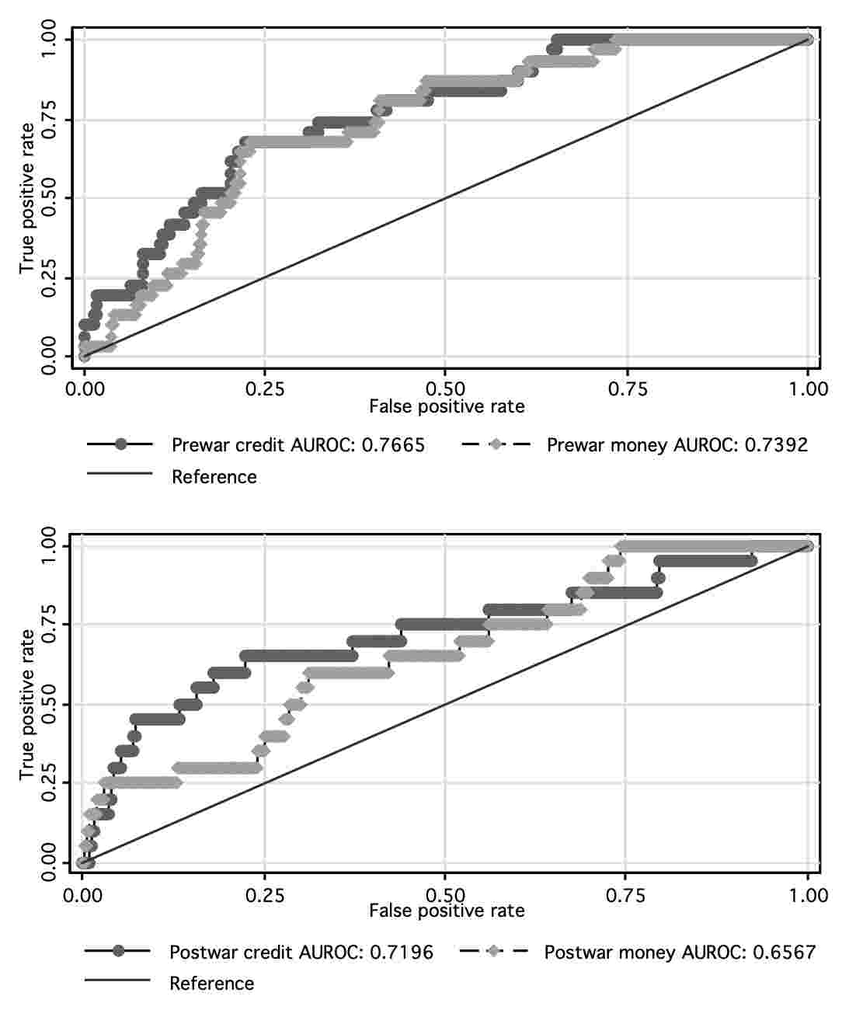

**Conclusion: credit matters, not money.**

#### Robustness checks

1. The role of asset price: possible feedback loop between asset values and lending reserves
   1. Stock price per se pose financial stability risk? – Inclusion of lags of stock prices, their overall contribution is very small.
   2. Asset price boom accompanied by increasing leverage? – Inclusion of interaction terms, the odds of financial crises increase.

$$\text{logit}(p_{it}) \sim \Delta_5\log\text{Loan}_{it} + \Delta_5\log\text{Stock}_{it}
+ \Delta_5\log\text{Loan}_{it} \times \Delta_5\log\text{Stock}_{it}$$

2. Crisis probabilities grow as financial depth grows. Inclusion of credit-to-GDP has positive coefficient. More complex financial systems are inherently more risky.

#### Conclusion

1. The analysis lends support to the idea that financial crisis can be viewed as “credit booms gone wrong”.
2. Historical evidence suggests that credit has a constructive role to play in central bank policy.
3. The evidence raises the possibility that the fianncial sector is quite capable of creating its own shocks.

© Original paper: [download](https://doi.org/10.1257/aer.102.2.1029)